# practice 5.1 mapping

R13B42015

2024-11-02

Introduction:

**⚠ Practice 5.1** Using the `rgbif` package download data from any species. Make a nice map of the distribution of the selected species. fix projection problem when plotting map. The map can be static or interactive.

## Introduce: Lycophytes

Lycophytes are a group of vascular plants, including clubmosses, often classified in the division Lycopodiophyta or Lycophyta. They represent one of the oldest lineages of living vascular plants, with some extinct species dating back to the Silurian period (about 425 million years ago). During the Carboniferous period, lycophytes dominated and included tree-like forms such as Lepidodendrales, some over 40 meters tall, although extant lycophytes are relatively small.

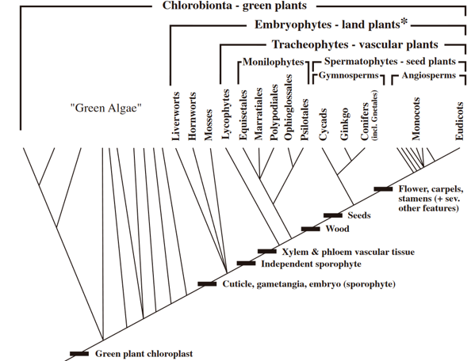

(Simpson, M. G. (2006). Plant Systematics.)

## Taiwan Isoetes

Taiwan Isoetes (Scientific name: Isoetes taiwanensis), also known as water grass (Tsuí-kú-tshài), is the only species of the Isoetes genus found in Taiwan, primarily distributed in Dream Lake of Qixing Mountain in Yangmingshan National Park. This perennial aquatic herbaceous plant has been present for about 5,000 years and is a rare endemic species. Taiwan Isoetes originated approximately 250 million years ago during the Triassic period and is considered a living fossil. Most of its close relatives became extinct during the Cretaceous, leaving only this low-growing form of Isoetes, which is significant in evolutionary studies. This plant produces spores but does not form seeds, pollen, or fruits, and has two varieties: Taiwan Isoetes (Isoetes taiwanensis var. taiwanensis) and Kinmen Isoetes (Isoetes taiwanensis var. kinmenensis).

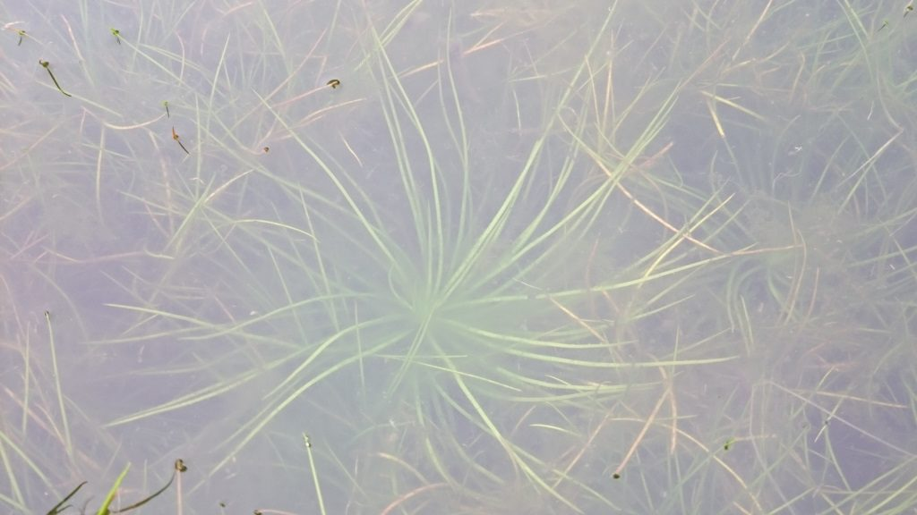

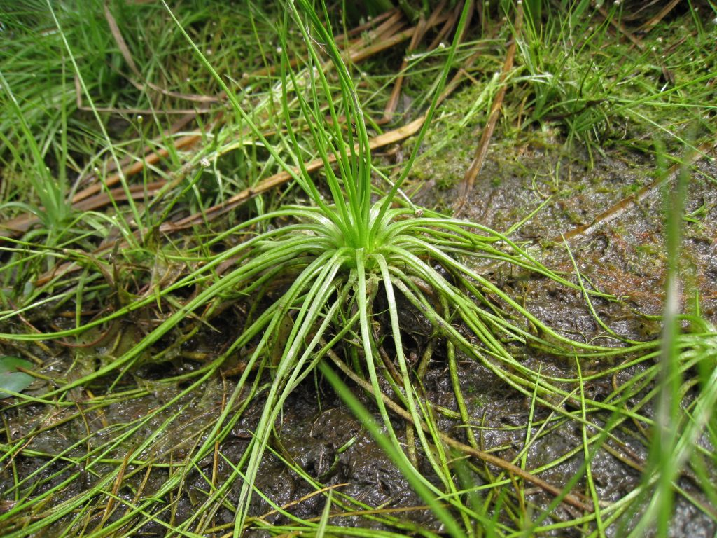

The above two images show Taiwan Isoetes both submerged in water and exposed to the air. The sources of both images are National Geographic (https://www.natgeomedia.com/environment/article/content-6150.html).

```r
library(rgbif) # for download dataset
library(dplyr)
library(leaflet) # for mapping
```

```r
# Get data for Common House Sparrow
species_data <- occ_search(scientificName = "Isoetes taiwanensis",
                           hasCoordinate=T,
                           basisOfRecord='HUMAN_OBSERVATION',
                           limit = 1000)
head(species_data$data)
```

```
## # A tibble: 6 × 86
##   key        scientificName   decimalLatitude decimalLongitude issues datasetKey
##   <chr>      <chr>                      <dbl>            <dbl> <chr>  <chr>
## 1 4519136491 Isoetes taiwane…            25.1             122. cdc,c… 50c9509d-…
## 2 4519102143 Isoetes taiwane…            25.1             122. cdc,c… 50c9509d-…
## 3 4950351095 Isoetes taiwane…            25.0             121. cdc,c… 50c9509d-…
## 4 4867995100 Isoetes taiwane…            25.0             122. cdc,c… 50c9509d-…
## 5 4067721452 Isoetes taiwane…            25.1             122. cdc,c… 50c9509d-…
## 6 4165562495 Isoetes taiwane…            25.1             122. cdc,c… 50c9509d-…
## # ℹ 80 more variables: publishingOrgKey <chr>, installationKey <chr>,
## #   hostingOrganizationKey <chr>, publishingCountry <chr>, protocol <chr>,
## #   lastCrawled <chr>, lastParsed <chr>, crawlId <int>, basisOfRecord <chr>,
## #   occurrenceStatus <chr>, taxonKey <int>, kingdomKey <int>, phylumKey <int>,
## #   classKey <int>, orderKey <int>, familyKey <int>, genusKey <int>,
## #   speciesKey <int>, acceptedTaxonKey <int>, acceptedScientificName <chr>,
## #   kingdom <chr>, phylum <chr>, order <chr>, family <chr>, genus <chr>, …
```

```r
# Chinese interactive map
leaflet(species_data$data) %>%
  addTiles() %>%
  addCircles(lng = ~decimalLongitude, lat = ~decimalLatitude,
             radius = 50,
             popup = ~paste(scientificName)) %>%
  addScaleBar(position = "bottomright") %>%
  addMeasure() %>%
  addControl("<strong>Isoetes taiwanensis Distribution Map</strong>", position = "topright",
             className = "leaflet-control-custom")
```

[interactive chart not shown]

```r
# English interactive map
leaflet(species_data$data) %>%
  addProviderTiles(providers$CartoDB.Positron) %>%
  addCircles(
    lng = ~decimalLongitude,
    lat = ~decimalLatitude,
    radius = 50,
    fillOpacity = 5,
    stroke = TRUE,
    popup = ~paste(scientificName),
  ) %>%
  addScaleBar(position = "bottomright") %>%
  addMeasure() %>%
  addControl("<strong>Isoetes taiwanensis Distribution Map</strong>", position = "topright",
             className = "leaflet-control-custom")
```

[interactive chart not shown]